# ads_creation

### Multivariate Sales Forecasting - German Retail Chain - Analytical Dataset Creation

#### Avinash Pasupulate

avinash.pasupulate@gmail.com  
www.avinash.pasupulate.com

### Introduction:

Rossmann operates over 3,000 drug stores in 7 European countries. Currently, Rossmann store managers are tasked with predicting their daily sales for up to six weeks in advance. Store sales are influenced by many factors, including promotions, competition, school and state holidays, seasonality, and locality. With thousands of individual managers predicting sales based on their unique circumstances, the accuracy of results can be quite varied.

The challenge is to predict 6 weeks of daily sales for 1,115 stores located across Germany. Reliable sales forecasts enable store managers to create effective staff schedules that increase productivity and motivation.

### Notebooks in Series:

This notebook is the first of the several notebooks listed below;

1. [ADS Creation with Feature Extraction and Mining Exogenous Data](http://nbviewer.jupyter.org/github/avinashpasupulate/multivariate_sales_forecasting_german_retail_chain/blob/master/ads_creation.ipynb)
2. Exploratory Data Analysis
3. Multivariate Forecasting

The [github link](https://github.com/avinashpasupulate/multivariate_sales_forecasting_german_retail_chain) also contains several excel files which are used as master files to map the exogenous data collected from different sources (links provided below).

### Supporting Files & Links:

1. [Master Files](https://github.com/avinashpasupulate/multivariate_sales_forecasting_german_retail_chain/tree/master/data/external_data)
2. [List of German state holidays by region](https://www.timeanddate.com/holidays/germany/)
3. [List of German school holidays](https://www.tuxx.uk/countries/germany/schoolholidays/2018/)
4. [Google trend data for "Rossmann" in Germany](https://trends.google.com/trends/explore?cat=18&date=2013-01-01%202017-01-01&geo=DE&q=rossmann)
5. [Dates for World Cup 2014](https://www.worldfootball.net/all_matches/wm-2014-in-brasilien/)
6. [Asylum applicant data](https://ec.europa.eu/eurostat/data/database)
7. [Consumer Price Index (CPI)](https://tradingeconomics.com/germany/consumer-price-index-cpi)
8. Historical Weather data

### Next Steps:

1. Cleanup code
2. Explore created dataset (Univariate and Multivariate)
3. Use multivariate methods to forecast sales

```python
import os
import copy
import json
import requests
import urllib3
import warnings
import calendar
import subprocess
#import openweather
import numpy as np
import pandas as pd
import seaborn as sns
import matplotlib.pyplot as plt
from geopy import geocoders
from bs4 import BeautifulSoup as bs
from pytrends.request import TrendReq
from tqdm._tqdm_notebook import tqdm_notebook

tqdm_notebook.pandas()
%matplotlib inline
warnings.filterwarnings('ignore')
pd.set_option('display.max_columns', 100)
```

```python
cwd = os.getcwd()
```

```python
#list all files in data folder
print(subprocess.check_output(['ls','data/']).decode('UTF-8'))
```

```
external_data
processed_data
raw_data
```

```python
#importing all files, considering onle two files test
#and store since sales data is not available in test station

store = pd.read_csv(cwd+'/data/raw_data/store.csv')
test = pd.read_csv(cwd+'/data/raw_data/test.csv')
train = pd.read_csv(cwd+'/data/raw_data/train.csv')
date_master = pd.read_excel(cwd+'/data/external_data/date_master.xlsx', sheet_name='date_master')
google_trends = pd.read_csv(cwd+'/data/external_data/google_trends.csv')
```

### Description of Dataset

Data fields Most of the fields are self-explanatory. The following are descriptions for those that aren't.

- **Id** - an Id that represents a (Store, Date) duple within the test set
- **Store** - a unique Id for each store
- **Sales** - the turnover for any given day (this is what you are predicting)
- **Customers** - the number of customers on a given day
- **Open** - an indicator for whether the store was open: 0 = closed, 1 = open
- **StateHoliday** - indicates a state holiday. Normally all stores, with few exceptions, are closed on state holidays. Note that all schools are closed on public holidays and weekends. a = public holiday, b = Easter holiday, c = Christmas, 0 = None
- **SchoolHoliday** - indicates if the (Store, Date) was affected by the closure of public schools
- **StoreType** - differentiates between 4 different store models: a, b, c, d
- **Assortment** - describes an assortment level: a = basic, b = extra, c = extended
- **CompetitionDistance** - distance in meters to the nearest competitor store
- **CompetitionOpenSince[Month/Year]** - gives the approximate year and month of the time the nearest competitor was opened
- **Promo** - indicates whether a store is running a promo on that day
- **Promo2** - Promo2 is a continuing and consecutive promotion for some stores: 0 = store is not participating, 1 = store is participating
- **Promo2Since[Year/Week]** - describes the year and calendar week when the store started participating in Promo2
- **PromoInterval** - describes the consecutive intervals Promo2 is started, naming the months the promotion is started anew. E.g. "Feb,May,Aug,Nov" means each round starts in February, May, August, November of any given year for that store

```python
#creating working copy of the train data
sales = copy.deepcopy(train)
```

### Identifying regions using state and school holidays

Using union and intersections of german state and school holidays to identigy regions

```python
#replacing categories in StateHoliday column
holmap = {'0':0, 'a':'public holiday', 'b':'easter holiday', 'c':'christmas holiday', 0:0}
sales.StateHoliday = sales.StateHoliday.map(holmap)
```

```python
#created date_holiday_master with list of holidays
#merging the train dataset with the date holiday master created with excel
sales.rename(columns={'Date':'date'}, inplace=True)
date_master.rename(columns={'date ':'date'}, inplace=True)
sales['date']=pd.to_datetime(sales['date'])
sales = sales.merge(date_master, how='left', on='date', suffixes={'','_dm'})
```

```python
#getting only required columns
sales=sales[['Store', 'date', 'Sales', 'Customers', 'Open', 'Promo',
       'StateHoliday', 'SchoolHoliday', 'year', 'day',
       'iso_weeknum', 'weekday', 'month', 'seasons', 'quarter',
       'holidays', 'holiday_type', 'regions_observed']]
sales_cp = copy.deepcopy(sales)
```

```python
#recoding categories in the regions_observed column
sales_cp.regions_observed.unique()
```

```
array([nan, 'BW, BY, HE, NRW, RLP, SL', 'B, BB, MVP, SN, ST, TH',
       'Brandenburg', 'BW, BY, ST', 'Saxony', 'BW, BY, NRW, RLP, SL',
       'BB, MVP, SN, ST, TH', 'Bavaria, Saarland', 'Bavaria*',
       'All except BB', 'BW,\xa0BY,\xa0NRW,\xa0RLP,\xa0SL',
       'BB,\xa0MVP,\xa0SN,\xa0ST,\xa0TH',
       'B,\xa0BB,\xa0MVP,\xa0SN,\xa0ST,\xa0TH',
       'BW,\xa0BY,\xa0HE,\xa0NRW,\xa0RLP,\xa0SL', 'All except\xa0BB',
       'BW,\xa0BY,\xa0ST'], dtype=object)
```

mapping all regions to remove unwanted characters.  
*regex could have been used here to replace certain region names*

```python
state_map = {'nan':None,
'BW, BY, HE, NRW, RLP, SL':'BW, BY, HE, NW, RP, SL',
'B, BB, MVP, SN, ST, TH':'B, BB, MV, SN, ST, TH',
'Brandenburg':'BB',
'BW, BY, ST':'BW, BY, ST',
'Saxony':'SN',
'BW, BY, NRW, RLP, SL':'BW, BY, NW, RP, SL',
'BB, MVP, SN, ST, TH':'BB, MV, SN, ST, TH',
'Bavaria, Saarland':'BY, SL',
'Bavaria*':'BY',
'All except BB': 'BW, BY, BE, HB, HH, HE, NI, MV, RP, SL, SN, ST, SH, TH, NW',
'BW,\xa0BY,\xa0NRW,\xa0RLP,\xa0SL': 'BW, BY, NW, RP, SL',
'BB,\xa0MVP,\xa0SN,\xa0ST,\xa0TH':'BB, MV, SN, ST, TH',
'B,\xa0BB,\xa0MVP,\xa0SN,\xa0ST,\xa0TH':'B, BB, MV, SN, ST, TH',
'BW,\xa0BY,\xa0HE,\xa0NRW,\xa0RLP,\xa0SL':'BW, BY, HE, NW, RP, SL',
'All except\xa0BB':'BW, BY, BE, HB, HH, HE, NI, MV, RP, SL, SN, ST, SH, TH, NW',
'BW,\xa0BY,\xa0ST':'BW, BY, ST'}
sales_cp.regions_observed = sales_cp.regions_observed.map(state_map)
```

```python
#categories in regions_observed after recoding
sales_cp.regions_observed.unique()
```

```
array([nan, 'BW, BY, HE, NW, RP, SL', 'B, BB, MV, SN, ST, TH', 'BB',
       'BW, BY, ST', 'SN', 'BW, BY, NW, RP, SL', 'BB, MV, SN, ST, TH',
       'BY, SL', 'BY',
       'BW, BY, BE, HB, HH, HE, NI, MV, RP, SL, SN, ST, SH, TH, NW'],
      dtype=object)
```

```python
#subsetting data with only stores and regions_observed columns
#sales_cp.loc[sales_cp.StateHoliday!='public holiday', 'regions_observed'] = None
state_hol = sales_cp[sales_cp.StateHoliday=='public holiday']
state_hol_sub = state_hol[['Store','regions_observed']]
hol_agg = state_hol_sub.groupby(['regions_observed'])['Store'].nunique().reset_index()
```

```python
#un-processed aggregation with overlapping regions
hol_agg
```

|  | regions_observed | Store |
| --- | --- | --- |
| 0 | BB, MV, SN, ST, TH | 167 |
| 1 | BW, BY, HE, NW, RP, SL | 766 |
| 2 | BW, BY, NW, RP, SL | 579 |
| 3 | BW, BY, ST | 309 |
| 4 | BY, SL | 180 |
| 5 | SN | 75 |

```python
#plotting number os unique stores in initial merge
#ax = sns.barplot(x=hol_agg.Store, y=hol_agg.regions_observed)
```

```python
#creating subsets with the region clusters for finding intersect and union of the datasets
reg_1 = state_hol_sub[state_hol_sub.regions_observed=='BW, BY, ST']
reg_2 = state_hol_sub[state_hol_sub.regions_observed=='BY, SL']
reg_3 = state_hol_sub[state_hol_sub.regions_observed=='BW, BY, NW, RP, SL']
reg_4 = state_hol_sub[state_hol_sub.regions_observed=='BW, BY, HE, NW, RP, SL']
reg_5 = state_hol_sub[state_hol_sub.regions_observed=='BB, MV, SN, ST, TH']
```

```python
SN = state_hol_sub[state_hol_sub.regions_observed=='SN']
```

```python
BY = pd.DataFrame(np.intersect1d(reg_1.Store, reg_2.Store))
BY = state_hol_sub[state_hol_sub.Store.isin(BY[0])].drop_duplicates()
```

```python
BW_ST = pd.DataFrame(np.setxor1d(reg_1.Store, BY.Store))
BW_ST = state_hol_sub[state_hol_sub.Store.isin(BW_ST[0])].drop_duplicates()
BW = pd.DataFrame(np.intersect1d(reg_3.Store, BW_ST.Store))
BW = state_hol_sub[state_hol_sub.Store.isin(BW[0])].drop_duplicates()
```

```python
ST = pd.DataFrame(np.setxor1d(BW.Store, BW_ST.Store))
ST = state_hol_sub[state_hol_sub.Store.isin(ST[0])].drop_duplicates()
```

```python
SL = pd.DataFrame(np.setxor1d(reg_2.Store, BY.Store))
SL = state_hol_sub[state_hol_sub.Store.isin(SL[0])].drop_duplicates()
```

```python
#for some reason HE also seems to contain SN, removing from the subset
HE_SN = pd.DataFrame(np.setxor1d(reg_3.Store, reg_4.Store))
HE_SN = state_hol_sub[state_hol_sub.Store.isin(HE_SN[0])].drop_duplicates()
HE = pd.DataFrame(np.setxor1d(HE_SN.Store, SN.Store))
HE = state_hol_sub[state_hol_sub.Store.isin(HE[0])].drop_duplicates()
```

```python
NW_RP_1 = pd.DataFrame(np.setxor1d(reg_3.Store, BW.Store))
NW_RP_1 = state_hol_sub[state_hol_sub.Store.isin(NW_RP_1[0])].drop_duplicates()
NW_RP_2 = pd.DataFrame(np.setxor1d(NW_RP_1.Store, BY.Store))
NW_RP_2 = state_hol_sub[state_hol_sub.Store.isin(NW_RP_2[0])].drop_duplicates()
NW_RP = pd.DataFrame(np.setxor1d(NW_RP_2.Store, SL.Store))
NW_RP = state_hol_sub[state_hol_sub.Store.isin(NW_RP[0])].drop_duplicates()
```

```python
BB_MV_TH_1 = pd.DataFrame(np.setxor1d(reg_5.Store, SN.Store))
BB_MV_TH_1 = state_hol_sub[state_hol_sub.Store.isin(BB_MV_TH_1[0])].drop_duplicates()
BB_MV_TH = pd.DataFrame(np.setxor1d(BB_MV_TH_1.Store, ST.Store))
BB_MV_TH = state_hol_sub[state_hol_sub.Store.isin(BB_MV_TH[0])].drop_duplicates()
```

```python
#finding the stores all over germany except for the ones listed above
ALL = pd.DataFrame(sales_cp['Store'].unique())
ALL_1 = pd.DataFrame(np.setxor1d(ALL[0], reg_4.Store))
ALL_1 = state_hol_sub[state_hol_sub.Store.isin(ALL_1[0])].drop_duplicates()
BE_HB_HH_NI_SH = pd.DataFrame(np.setxor1d(ALL_1.Store, reg_5.Store))
BE_HB_HH_NI_SH = ALL_1[ALL_1.Store.isin(BE_HB_HH_NI_SH[0])].drop_duplicates()
```

```python
#naming dataframes and looking for common values
SN.name='SN'
ST.name='ST'
BW.name='BW'
BY.name='BY'
HE.name='HE'
SL.name='SL'
NW_RP.name='NW_RP'
BB_MV_TH.name='BB_MV_TH'
BE_HB_HH_NI_SH.name='BE_HB_HH_NI_SH'
```

```python
#checking if there is overlapping between current classification
city = [SN, ST, BW, BY, HE, SL, NW_RP, BB_MV_TH, BE_HB_HH_NI_SH]
for i in range(len(city)):
    for j in range(len(city)):
        if np.array_equal(city[i].Store, city[j].Store):
            print(city[i].name,city[j].name,np.array_equal(city[i].Store, city[j].Store))
```

```
SN SN True
ST ST True
BW BW True
BY BY True
HE HE True
SL SL True
NW_RP NW_RP True
BB_MV_TH BB_MV_TH True
BE_HB_HH_NI_SH BE_HB_HH_NI_SH True
```

```python
#adding columns in subsets with mapped region
SN['mapped_region'] = "SN"
ST['mapped_region'] = "ST"
BW['mapped_region'] = "BW"
BY['mapped_region'] = "BY"
HE['mapped_region'] = "HE"
SL['mapped_region'] = "SL"
NW_RP['mapped_region'] = "NW_RP"
BB_MV_TH['mapped_region'] = "BB_MV_TH"
BE_HB_HH_NI_SH['mapped_region'] = "BE_HB_HH_NI_SH"
```

```python
#combining all store-region mapping subsets
frames = [SN, ST, BW, BY, HE, SL, NW_RP, BB_MV_TH, BE_HB_HH_NI_SH]
store_reg = pd.concat(frames).drop_duplicates()
```

```python
#further identifying regions for above clusters using the school holiday information
school_hols = pd.read_excel(cwd+'/data/external_data/schol_out_trans.xlsx', sheet_name='transformed_hols')
```

```python
school_hols.head()
```

|  | region | region_code | holiday | key | year | from | to |
| --- | --- | --- | --- | --- | --- | --- | --- |
| 0 | Baden-Württemberg | BW | autumn | Baden-WürttembergBWautumn2013 | 2013 | 2013-10-28 | 2013-10-30 |
| 1 | Baden-Württemberg | BW | christmas | Baden-WürttembergBWchristmas2013 | 2013 | 2013-12-23 | 2013-01-05 |
| 2 | Baden-Württemberg | BW | easter | Baden-WürttembergBWeaster2013 | 2013 | 2013-03-25 | 2013-04-05 |
| 3 | Baden-Württemberg | BW | pentecost | Baden-WürttembergBWpentecost2013 | 2013 | 2013-05-21 | 2013-06-01 |
| 4 | Baden-Württemberg | BW | summer | Baden-WürttembergBWsummer2013 | 2013 | 2013-07-25 | 2013-09-07 |

NW_RP BB_MV_TH BE_HB_HH_NI_SH

```python
#checking if all stores from a region have holiday on the same day
train.loc[train.Store.isin(HE.Store)].groupby('Date')['SchoolHoliday'].sum().value_counts()

# 0 denotes no holidays for 749 stores and all have holidays on same day
```

```
0      749
112    193
Name: SchoolHoliday, dtype: int64
```

```python
train.loc[train.Store.isin(BW.Store)].groupby('Date')['SchoolHoliday'].sum().value_counts()
```

```
0     787
73    155
Name: SchoolHoliday, dtype: int64
```

```python
train.loc[train.Store.isin(BY.Store)].groupby('Date')['SchoolHoliday'].sum().value_counts()
```

```
0      634
180    124
Name: SchoolHoliday, dtype: int64
```

```python
train.loc[train.Store.isin(SN.Store)].groupby('Date')['SchoolHoliday'].sum().value_counts()
```

```
0     770
75    172
Name: SchoolHoliday, dtype: int64
```

```python
train.loc[train.Store.isin(ST.Store)].groupby('Date')['SchoolHoliday'].sum().value_counts()
```

```
0     774
56    168
Name: SchoolHoliday, dtype: int64
```

```python
#some stores have holidays on different so probably belong to different regions
train.loc[train.Store.isin(NW_RP.Store)].groupby('Date')['SchoolHoliday'].sum().value_counts()

#there is overlapping of holidays from different regions
```

```
0      722
326    100
286     70
40      50
Name: SchoolHoliday, dtype: int64
```

```python
#stores in this category may belong to the same region
train.loc[train.Store.isin(BB_MV_TH.Store)].groupby('Date')['SchoolHoliday'].sum().value_counts()
```

```
0     775
36    167
Name: SchoolHoliday, dtype: int64
```

```python
#checking if there is a school holiday which is mutually exclusive
#26-03-2015 is exclusive to RP region
TH = train.loc[train.Store.isin(BB_MV_TH.Store)&(train.SchoolHoliday==1), 'Store'].values
TH = state_hol_sub.loc[state_hol_sub.Store.isin(TH)].drop_duplicates()

RP = train.loc[train.Date=='2015-03-26'].loc[train.Store.isin(NW_RP.Store)].loc[train.SchoolHoliday==1,'Store'].values
RP = state_hol_sub.loc[state_hol_sub.Store.isin(RP)].drop_duplicates()
NW = np.setxor1d(NW_RP.Store,RP.Store)
NW = state_hol_sub[state_hol_sub.Store.isin(NW)].drop_duplicates()
```

```python
#this category has stores from multiple regions
train.loc[train.Store.isin(BE_HB_HH_NI_SH.Store)].groupby('Date')['SchoolHoliday'].sum().value_counts()
```

```
0      618
22      84
257     80
28      42
235     24
229     24
92      15
114     13
143     10
120     10
115      8
207      6
137      5
256      1
165      1
50       1
Name: SchoolHoliday, dtype: int64
```

```python
#l = ['BE','HB','HH','NI','SH']
#school_hols[(school_hols.region_code.isin(l))&(school_hols.year==2013)]
```

```python
#HE region seems to have a holiday on 26/10/2013
#train.loc[(train.Date=='2015-03-02')&(train.Store.isin(BE_HB_HH_NI_SH)),'Store'].values
```

```python
#train.loc[train.Date=='2015-03-02'].loc[train.Store.isin(BE_HB_HH_NI_SH)].loc[train.SchoolHoliday==1,'Store'].values
HH = train.loc[(train.Date=='2015-03-02')&(train.Store.isin(BE_HB_HH_NI_SH.Store))&(train.SchoolHoliday==1),'Store'].values
#removing HH from the cluster
BE_HB_NI_SH = np.setxor1d(BE_HB_HH_NI_SH.Store,HH)

HH = state_hol_sub[state_hol_sub.Store.isin(HH)].drop_duplicates()
```

```python
SH = train.loc[(train.Date=='2015-04-17')&(train.Store.isin(BE_HB_NI_SH))&(train.SchoolHoliday==1),'Store'].values
BE_HB_NI = np.setxor1d(BE_HB_NI_SH, SH)

SH = state_hol_sub[state_hol_sub.Store.isin(SH)].drop_duplicates()
```

```python
BE = train.loc[(train.Date=='2015-03-25')&(train.Store.isin(BE_HB_NI))&(train.SchoolHoliday==1),'Store'].values

HB_NI = np.setxor1d(BE_HB_NI, BE)
BE = state_hol_sub[state_hol_sub.Store.isin(BE)].drop_duplicates()
```

```python
HB = train.loc[(train.Store.isin(HB_NI))&(train.Date=='2014-09-10')&(train.SchoolHoliday==1), 'Store'].values

NI = np.setxor1d(HB_NI, HB)
HB = state_hol_sub[state_hol_sub.Store.isin(HB)].drop_duplicates()
NI = state_hol_sub[state_hol_sub.Store.isin(NI)].drop_duplicates()
```

```python
#naming dataframes and looking for common values
SN.name='SN'
ST.name='ST'
BW.name='BW'
BY.name='BY'
HE.name='HE'
BE.name='BE'
NW.name='NW'
RP.name='RP'
TH.name='TH'
HB.name='HB'
HH.name='HH'
NI.name='NI'
SH.name='SH'
```

```python
#checking if there is no overlapping of mapped regions (True denotes there is no overlapping of stores)
city = [SN, ST, BW, BY, HE, NW, RP, TH, BE, HB, HH, NI, SH]
for i in range(len(city)):
    for j in range(len(city)):
        if np.array_equal(city[i].Store, city[j].Store):
            print(city[i].name,city[j].name,np.array_equal(city[i].Store, city[j].Store))
```

```
SN SN True
ST ST True
BW BW True
BY BY True
HE HE True
NW NW True
RP RP True
TH TH True
BE BE True
HB HB True
HH HH True
NI NI True
SH SH True
```

```python
#adding columns in subsets with mapped region
SN['mapped_region'] = "SN"
ST['mapped_region'] = "ST"
BW['mapped_region'] = "BW"
BY['mapped_region'] = "BY"
HE['mapped_region'] = "HE"
BE['mapped_region'] = "BE"
NW['mapped_region'] = "NW"
RP['mapped_region'] = "RP"
TH['mapped_region'] = "TH"
HB['mapped_region'] = "HB"
HH['mapped_region'] = "HH"
NI['mapped_region'] = "NI"
SH['mapped_region'] = "SH"
```

```python
#combining all store-region mapping subsets
frames = [SN, ST, BW, BY, HE, BE, NW, RP, TH, HB, HH, NI, SH]
store_reg = pd.concat(frames).drop_duplicates()
```

```python
#processed mapping sums to 1115 stores
store_reg.groupby(['mapped_region'])['Store'].nunique().reset_index()
```

|  | mapped_region | Store |
| --- | --- | --- |
| 0 | BE | 22 |
| 1 | BW | 73 |
| 2 | BY | 180 |
| 3 | HE | 112 |
| 4 | HH | 28 |
| 5 | NI | 92 |
| 6 | NW | 286 |
| 7 | RP | 40 |
| 8 | SH | 115 |
| 9 | SN | 75 |
| 10 | ST | 56 |
| 11 | TH | 36 |

```python
len(train.loc[~train.Store.isin(store_reg.Store), 'Store'].drop_duplicates().values)
```

```
0
```

```python
len(store_reg['Store'].drop_duplicates())
```

```
1115
```

```python
store_reg[['Store', 'mapped_region']].reset_index(drop = True).head()
```

|  | Store | mapped_region |
| --- | --- | --- |
| 0 | 5 | SN |
| 1 | 6 | SN |
| 2 | 55 | SN |
| 3 | 57 | SN |
| 4 | 60 | SN |

```python
sales = sales.iloc[:,:15]
sales = sales.merge(store_reg[['Store', 'mapped_region']], how = 'left', on='Store', suffixes={'','_mapreg'})
```

### Acquiring and including Google trends data

Mapping week wise historical google trend data (SVI - Search volume Index) to the sales dataset downloaded from

https://trends.google.com/trends/explore?cat=18&date=2013-01-01%202017-01-01&geo=DE&q=rossmann

```python
#getting google trend information
pytrends = TrendReq(hl='en-US',tz='60')
kw_list = ['rossmann']
#unable to collect google trends data at a daily level, downloading manually
pytrends.build_payload(kw_list, cat=0, timeframe='2013-01-01 2016-01-01', geo='DE', gprop='froogle')
ross_trend = pytrends.interest_over_time()
```

pytrends and google trends doesnt provide daily data for more than 90 days, so downloading weekly data from google trends seems to be a faster option

```python
ross_trend = ross_trend.reset_index()[['date','rossmann']]
#ross_trend['week_number']=ross_trend['date'].apply(lambda x: x.)
#ross_trend['date'].isocalendar()[0]
ross_trend['year'] = ross_trend['date'].dt.year
ross_trend['week_num'] = ross_trend['date'].dt.week

#google trend data by week
ross_trend.head()
```

|  | date | rossmann | year | week_num |
| --- | --- | --- | --- | --- |
| 0 | 2013-01-06 | 33 | 2013 | 1 |
| 1 | 2013-01-13 | 15 | 2013 | 2 |
| 2 | 2013-01-20 | 28 | 2013 | 3 |
| 3 | 2013-01-27 | 42 | 2013 | 4 |
| 4 | 2013-02-03 | 9 | 2013 | 5 |

```python
sales['trend_key'] = sales['year'].astype(str)+'-'+sales['iso_weeknum'].astype(str)
ross_trend['trend_key'] = ross_trend['year'].astype(str)+'-'+ross_trend['week_num'].astype(str)

ross_trend.head()
```

|  | date | rossmann | year | week_num | trend_key |
| --- | --- | --- | --- | --- | --- |
| 0 | 2013-01-06 | 33 | 2013 | 1 | 2013-1 |
| 1 | 2013-01-13 | 15 | 2013 | 2 | 2013-2 |
| 2 | 2013-01-20 | 28 | 2013 | 3 | 2013-3 |
| 3 | 2013-01-27 | 42 | 2013 | 4 | 2013-4 |
| 4 | 2013-02-03 | 9 | 2013 | 5 | 2013-5 |

```python
ross_trend.columns = ['date_t', 'google_svi', 'year_t', 'week_num_t', 'trend_key']
```

```python
#mapping in google trends data by week number
sales = sales.merge(ross_trend, how='left', on='trend_key', suffixes={'','_trend'})
```

```python
sales.head()
```

|  | Store | date | Sales | Customers | Open | Promo | StateHoliday | SchoolHoliday | year | day | iso_weeknum | weekday | month | seasons | quarter | mapped_region | trend_key | date_t | google_svi | year_t | week_num_t |
| --- | --- | --- | --- | --- | --- | --- | --- | --- | --- | --- | --- | --- | --- | --- | --- | --- | --- | --- | --- | --- | --- |
| 0 | 1 | 2015-07-31 | 5263 | 555 | 1 | 1 | 0 | 1 | 2015 | 31 | 31 | Friday | July | Summer | 3 | HE | 2015-31 | 2015-08-02 | 51 | 2015 | 31 |
| 1 | 1 | 2015-07-31 | 5263 | 555 | 1 | 1 | 0 | 1 | 2015 | 31 | 31 | Friday | July | Summer | 3 | HE | 2015-31 | 2015-08-02 | 51 | 2015 | 31 |
| 2 | 2 | 2015-07-31 | 6064 | 625 | 1 | 1 | 0 | 1 | 2015 | 31 | 31 | Friday | July | Summer | 3 | TH | 2015-31 | 2015-08-02 | 51 | 2015 | 31 |
| 3 | 2 | 2015-07-31 | 6064 | 625 | 1 | 1 | 0 | 1 | 2015 | 31 | 31 | Friday | July | Summer | 3 | TH | 2015-31 | 2015-08-02 | 51 | 2015 | 31 |
| 4 | 3 | 2015-07-31 | 8314 | 821 | 1 | 1 | 0 | 1 | 2015 | 31 | 31 | Friday | July | Summer | 3 | NW | 2015-31 | 2015-08-02 | 51 | 2015 | 31 |

```
1. World Cup 2014 (major sport event)
2. European Immigrant Crisis (supplies for immigrants, rioters etc)
3. Macroeconomic variable - Consumer Price Index for Germany
```

List of notable events in german history; https://en.wikipedia.org/wiki/Timeline_of_German_history

Link to asylum application data by month: http://appsso.eurostat.ec.europa.eu/nui/show.do

Link to football worldcup dates: https://www.worldfootball.net/all_matches/wm-2014-in-brasilien/

```python
#including all dates (maybe provide extra weight/flag to days before and after germany has played)
wc_2014 = pd.read_html('https://www.worldfootball.net/all_matches/wm-2014-in-brasilien/')
wc_2014 = wc_2014[1]
wc_2014.columns = ['date', 'time', 'team_a', '1', 'team_b', '2', '3', '4']
dlab = ['1', '2', '3', '4']
wc_2014.drop(dlab, axis=1, inplace=True)
wc_2014['date'].fillna(method = 'ffill', inplace = True)
wc_2014['date']=pd.to_datetime(wc_2014['date'], errors='coerce')
wc_2014.dropna(axis = 0, inplace = True)
wc_2014.head()
```

|  | date | time | team_a | team_b |
| --- | --- | --- | --- | --- |
| 1 | 2014-12-06 | 21:00 | Brazil | Croatia |
| 2 | 2014-06-13 | 17:00 | Mexico | Cameroon |
| 3 | 2014-06-17 | 20:00 | Brazil | Mexico |
| 4 | 2014-06-18 | 23:00 | Cameroon | Croatia |
| 5 | 2014-06-23 | 21:00 | Cameroon | Brazil |

```python
#merging with the dataset
sales.loc[sales.date.isin(wc_2014.date), 'wc_days']=1
sales['wc_days'].fillna(0, inplace=True)
sales.wc_days = sales.wc_days.astype(int)
```

```python
#importing asylum applicants in germany for 2013, 2014, 2015
imm_app = pd.read_csv(cwd+'/data/external_data/migr_asyappctzm/migr_asyappctzm_1_Data.csv')
imm_app.head(2)
```

|  | TIME | GEO | CITIZEN | SEX | AGE | ASYL_APP | UNIT | Value | Flag and Footnotes |
| --- | --- | --- | --- | --- | --- | --- | --- | --- | --- |
| 0 | 2013M01 | Germany (until 1990 former territory of the FRG) | Extra-EU28 (current composition) | Total | Total | Asylum applicant | Person | 8,370 | NaN |
| 1 | 2013M01 | Germany (until 1990 former territory of the FRG) | Extra-EU28 (current composition) | Total | Total | First time applicant | Person | 7,505 | NaN |

```python
dlab1 = ['GEO', 'CITIZEN', 'SEX', 'AGE', 'ASYL_APP', 'UNIT', 'Flag and Footnotes']
imm_app = imm_app[imm_app['ASYL_APP']=='Asylum applicant'].drop(dlab1, axis=1)
imm_app.columns = ['year_month', 'num_asy_app']
```

```python
imm_app.head()
```

|  | year_month | num_asy_app |
| --- | --- | --- |
| 0 | 2013M01 | 8,370 |
| 2 | 2013M02 | 6,800 |
| 4 | 2013M03 | 6,500 |
| 6 | 2013M04 | 8,735 |
| 8 | 2013M05 | 8,580 |

```python
imm_app['year'],imm_app['month'] = imm_app.year_month.str.split('M', 1).str
imm_app['month'] = imm_app['month'].astype(int).apply(lambda x: calendar.month_name[x])
imm_app['year_month'] = imm_app['year'].astype(str)+'_'+imm_app['month'].astype(str)
```

```python
sales['year_month'] = sales['year'].astype(str)+'_'+sales['month'].astype(str)
```

```python
sales = sales.merge(imm_app, how='left', on='year_month', suffixes={'','_imm'})
```

```python
cpi = pd.read_csv(cwd+'/data/external_data/cpi_germany_13-15.csv')
cpi.columns = ['date', 'cpi']
```

```python
cpi['month'] = pd.DatetimeIndex(cpi['date']).month
cpi['year'] = pd.DatetimeIndex(cpi['date']).year
cpi['month'] = cpi['month'].apply(lambda x: calendar.month_name[x])
cpi['cpi_key'] = cpi['year'].astype(str)+'_'+cpi['month'].astype(str)
```

```python
sales['cpi_key'] = sales['year'].astype(str)+"_"+sales['month']
sales = sales.merge(cpi, how = 'left', on = 'cpi_key', suffixes = {'','_cpi'})
sales.head()
```

|  | Store | date | Sales | Customers | Open | Promo | StateHoliday | SchoolHoliday | year | day | iso_weeknum | weekday | month | seasons | quarter | mapped_region | trend_key | date_t | google_svi | year_t | week_num_t | wc_days | year_month | num_asy_app | year_imm | month_imm | cpi_key | date_cpi | cpi | … |
| --- | --- | --- | --- | --- | --- | --- | --- | --- | --- | --- | --- | --- | --- | --- | --- | --- | --- | --- | --- | --- | --- | --- | --- | --- | --- | --- | --- | --- | --- | --- |
| 0 | 1 | 2015-07-31 | 5263 | 555 | 1 | 1 | 0 | 1 | 2015 | 31 | 31 | Friday | July | Summer | 3 | HE | 2015-31 | 2015-08-02 | 51 | 2015 | 31 | 0 | 2015_July | 39,825 | 2015 | July | 2015_July | 2015-07-01 | 100.288454 | … |
| 1 | 1 | 2015-07-31 | 5263 | 555 | 1 | 1 | 0 | 1 | 2015 | 31 | 31 | Friday | July | Summer | 3 | HE | 2015-31 | 2015-08-02 | 51 | 2015 | 31 | 0 | 2015_July | 39,825 | 2015 | July | 2015_July | 2015-07-01 | 100.288454 | … |
| 2 | 2 | 2015-07-31 | 6064 | 625 | 1 | 1 | 0 | 1 | 2015 | 31 | 31 | Friday | July | Summer | 3 | TH | 2015-31 | 2015-08-02 | 51 | 2015 | 31 | 0 | 2015_July | 39,825 | 2015 | July | 2015_July | 2015-07-01 | 100.288454 | … |
| 3 | 2 | 2015-07-31 | 6064 | 625 | 1 | 1 | 0 | 1 | 2015 | 31 | 31 | Friday | July | Summer | 3 | TH | 2015-31 | 2015-08-02 | 51 | 2015 | 31 | 0 | 2015_July | 39,825 | 2015 | July | 2015_July | 2015-07-01 | 100.288454 | … |
| 4 | 3 | 2015-07-31 | 8314 | 821 | 1 | 1 | 0 | 1 | 2015 | 31 | 31 | Friday | July | Summer | 3 | NW | 2015-31 | 2015-08-02 | 51 | 2015 | 31 | 0 | 2015_July | 39,825 | 2015 | July | 2015_July | 2015-07-01 | 100.288454 | … |

```python
dcol = ['trend_key', 'date_t', 'year_t', 'week_num_t', 'year_month', 'year_imm', 'month_imm', 'date_cpi', 'cpi_key', 'month_cpi', 'year_cpi']
sales.drop(dcol, axis=1, inplace= True)
sales.head()
```

|  | Store | date | Sales | Customers | Open | Promo | StateHoliday | SchoolHoliday | year | day | iso_weeknum | weekday | month | seasons | quarter | mapped_region | google_svi | wc_days | num_asy_app | cpi |
| --- | --- | --- | --- | --- | --- | --- | --- | --- | --- | --- | --- | --- | --- | --- | --- | --- | --- | --- | --- | --- |
| 0 | 1 | 2015-07-31 | 5263 | 555 | 1 | 1 | 0 | 1 | 2015 | 31 | 31 | Friday | July | Summer | 3 | HE | 51 | 0 | 39,825 | 100.288454 |
| 1 | 1 | 2015-07-31 | 5263 | 555 | 1 | 1 | 0 | 1 | 2015 | 31 | 31 | Friday | July | Summer | 3 | HE | 51 | 0 | 39,825 | 100.288454 |
| 2 | 2 | 2015-07-31 | 6064 | 625 | 1 | 1 | 0 | 1 | 2015 | 31 | 31 | Friday | July | Summer | 3 | TH | 51 | 0 | 39,825 | 100.288454 |
| 3 | 2 | 2015-07-31 | 6064 | 625 | 1 | 1 | 0 | 1 | 2015 | 31 | 31 | Friday | July | Summer | 3 | TH | 51 | 0 | 39,825 | 100.288454 |
| 4 | 3 | 2015-07-31 | 8314 | 821 | 1 | 1 | 0 | 1 | 2015 | 31 | 31 | Friday | July | Summer | 3 | NW | 51 | 0 | 39,825 | 100.288454 |

### Acquiring temperature/weather data

- searching with addresses and nearest weather stations with historical information

```python
regmap = {'HE': 'Hessen', 'TH':'Thuringia', 'NW':'North Rhine Westfalia', 'NI':'Lower Saxony', 'SN':'Saxony', 'SH':'Schleswig Holstein', 'BE':'Berlin', 'BY':'Bavaria', 'BW':'Baden-Württemberg', 'RP':'Rhineland-Palatinate', 'ST':'Saxony-Anhalt', 'HH':'Hamburg'}
sales.mapped_region = sales.mapped_region.map(regmap)
```

```python
#getting latitude and longitude for the regions to identify weather station ids
g = geocoders.ArcGIS()
reg_df = pd.DataFrame(columns = ['region', 'latitude', 'longitude'])
for i in sales.mapped_region.unique():
    geo = g.geocode(i)
    reg_df = reg_df.append({'region': geo[0], 'latitude': geo[1][0], 'longitude': geo[1][1]}, ignore_index=True)
```

```python
#getting station ids from open weather
#ow = openweather.OpenWeather('get open weather api key')
#station = ow.find_stations_near(50.603974, 9.031721, 50)
```

```python
weather_stn = 'https://mesonet.agron.iastate.edu/sites/networks.php?network=DE__ASOS&format=csv&nohtml=on'
weather_data = 'https://mesonet.agron.iastate.edu/cgi-bin/request/asos.py?station=EDAC&station=EDAD&station=EDAH&station=EDAR&station=EDAS&station=EDBB&station=EDBC&station=EDBM&station=EDBT&station=EDCK&station=EDCP&station=EDDB&station=EDDC&station=EDDE&station=EDDF&station=EDDG&station=EDDH&station=EDDI&station=EDDK&station=EDDL&station=EDDM&station=EDDN&station=EDDP&station=EDDR&station=EDDS&station=EDDT&station=EDDV&station=EDDW&station=EDEF&station=EDEK&station=EDFE&station=EDFH&station=EDFM&station=EDGS&station=EDHI&station=EDHK&station=EDHL&station=EDIA&station=EDIC&station=EDIG&station=EDIH&station=EDIK&station=EDJA&station=EDKA&station=EDLE&station=EDLG&station=EDLN&station=EDLP&station=EDLV&station=EDLW&station=EDMA&station=EDMB&station=EDMO&station=EDNN&station=EDNY&station=EDOP&station=EDPH&station=EDPN&station=EDQD&station=EDQM&station=EDRZ&station=EDSB&station=EDTD&station=EDTL&station=EDTY&station=EDTZ&station=EDVE&station=EDVK&station=EDVV&station=EDWD&station=EDWE&station=EDXW&station=EDZB&station=EDZE&station=EDZH&station=EDZJ&station=ETAD&station=ETAR&station=ETAS&station=ETBA&station=ETBB&station=ETBS&station=ETEB&station=ETEH&station=ETEU&station=ETGB&station=ETGG&station=ETGI&station=ETGK&station=ETGM&station=ETGQ&station=ETGW&station=ETGY&station=ETGZ&station=ETHA&station=ETHB&station=ETHC&station=ETHE&station=ETHF&station=ETHI&station=ETHL&station=ETHM&station=ETHN&station=ETHR&station=ETHS&station=ETHT&station=ETIC&station=ETID&station=ETIE&station=ETIH&station=ETIK&station=ETIN&station=ETME&station=ETMK&station=ETML&station=ETMN&station=ETNA&station=ETND&station=ETNG&station=ETNH&station=ETNJ&station=ETNL&station=ETNN&station=ETNP&station=ETNS&station=ETNT&station=ETNU&station=ETNW&station=ETOR&station=ETOU&station=ETSA&station=ETSB&station=ETSE&station=ETSF&station=ETSH&station=ETSI&station=ETSL&station=ETSM&station=ETSN&station=ETSP&station=ETUL&station=ETUN&station=ETUO&station=ETUR&station=ETWM&station=KQAA&station=KQAB&station=KQAC&station=KQAK&station=KQAO&station=KQII&station=KQKT&station=KQKW&station=KQLB&station=KQQL&station=KQUB&data=tmpc&data=relh&year1=2013&month1=1&day1=1&year2=2015&month2=12&day2=31&tz=Etc%2FUTC&format=onlycomma&latlon=yes&direct=no&report_type=1&report_type=2'
```

```python
weather_stn = pd.read_csv(weather_stn)
```

```python
weather_stn.head()
```

|  | stid | station_name | lat | lon | elev | begints | iem_network |
| --- | --- | --- | --- | --- | --- | --- | --- |
| 0 | EDKA | Aachen Merzbruck | 50.82420 | 6.18700 | 191.069 | 2018-01-12 07:00:00-06 | DE__ASOS |
| 1 | EDAC | ALTENBURG-NOBITZ | 50.98182 | 12.50636 | 195.000 | 2011-01-03 01:20:00-06 | DE__ASOS |
| 2 | ETHA | ALTENSTADT/SCHON | 47.83639 | 10.87222 | 760.000 | 2011-08-22 22:20:00-05 | DE__ASOS |
| 3 | EDMA | AUGSBERG/MULHAUS | 48.42611 | 10.94306 | 463.000 | 2011-07-02 00:20:00-05 | DE__ASOS |
| 4 | EDDB | BERLIN/SCHONEFEL | 52.38222 | 13.53250 | 48.000 | 2010-12-31 18:20:00-06 | DE__ASOS |

```python
#weather_data = pd.read_csv(weather_data)
#weather_data.to_csv(cwd+r'/data/processed_data/german_weather_data.csv')
```

### Objective/To Do :

- Finding what stations lie within which region so that they can be mapped to their respective station

```python
#get google api key from google
key = 'get it from google'
key = 'AIzaSyCX1sRT9KcKCXVZIU2EP8PrxeH_FdxGP8Q'
def rev_code(lat, lon, key):
    url = "https://maps.googleapis.com/maps/api/geocode/json?"
    url += "latlng=%s,%s&sensor=false&key=%s" %(lat, lon, key)
    address = requests.get(url).json()
    comp = address['results'][0]['address_components']
    ad = []
    l = ['postal_town', 'administrative_area_level_2', 'administrative_area_level_1', 'country']
    for c in comp:
        if c['types'][0] in l:
            ad.append((c['long_name']+"-"+c['short_name']))
    return ad
```

```python
weather_stn['location'] = weather_stn.apply(lambda x: '|'.join(i for i in rev_code(x['lat'], x['lon'], key)), axis=1)
```

```python
loc = weather_stn['location'].str.split('|', expand=True)
weather_stn = weather_stn.join(loc)
```

```python
stn_info = copy.copy(weather_stn)
stn_info[2].unique()
#dropping '2' since it contains only one country information
stn_info.drop(2, axis=1, inplace=True)
#stn_info.drop('location', axis=1, inplace=True)
```

Although location mapping can be done in python, mapping a few values in excel with index match and re-importing was easier

```python
#stn_info[0].apply(lambda x: [i for i in x.split('-') if len(i)<4 else i])

stn_info['loc_codes'] = stn_info[0].apply(lambda x: [i if len(i)<4 else x for i in x.split('-')][1])
#stn_info.to_csv(cwd+r'/data/processed_data/stn_info.csv')
stn_info = pd.read_csv(cwd+r'/data/external_data/stn_info.csv')
```

```python
stn_info['region_code'].unique()
```

```
array(['NW', 'TH', 'BY', 'BB', 'BE', '-', 'NI', 'RP', 'ST', 'BW', 'SN',
       'HE', 'HH', 'MV', 'SH', 'Denmark'], dtype=object)
```

```python
weather_data = pd.read_csv(cwd+r'/data/external_data/german_weather_data.csv')
```

```python
weather_data.columns = ['sno', 'stid', 'valid', 'lon', 'lat', 'tmpc', 'relh']
weather_data.head()
```

|  | sno | stid | valid | lon | lat | tmpc | relh |
| --- | --- | --- | --- | --- | --- | --- | --- |
| 0 | 0 | ETOU | 2013-01-01 06:16 | 8.3254 | 50.0498 | 6.00 | 81.07 |
| 1 | 1 | ETAD | 2013-01-01 06:20 | 6.6992 | 49.9802 | 5.00 | 93.24 |
| 2 | 2 | EDDK | 2013-01-01 06:20 | 7.1586 | 50.8661 | 7.00 | 81.20 |
| 3 | 3 | EDXW | 2013-01-01 06:20 | 8.3405 | 54.9132 | 6.00 | 100.00 |
| 4 | 4 | EDDV | 2013-01-01 06:20 | 9.6797 | 52.4658 | 7.00 | 87.09 |

```python
weather_data = weather_data.merge(stn_info, on = 'stid', how='inner', suffixes={'_l','_r'})
weather_data.head()
```

|  | sno | stid | valid | lon_r | lat_r | tmpc | relh | station_name | lat_l | lon_l | elev | begints | iem_network | location | region_code |
| --- | --- | --- | --- | --- | --- | --- | --- | --- | --- | --- | --- | --- | --- | --- | --- |
| 0 | 0 | ETOU | 2013-01-01 06:16 | 8.3254 | 50.0498 | 6.00 | 81.07 | WIESBADEN (USA-A | 50.04982 | 8.3254 | 141.0 | 22/08/11 14:55 | DE__ASOS | Darmstadt-DA\|Hessen-HE\|Germany-DE | HE |
| 1 | 37 | ETOU | 2013-01-01 06:31 | 8.3254 | 50.0498 | 6.00 | 81.07 | WIESBADEN (USA-A | 50.04982 | 8.3254 | 141.0 | 22/08/11 14:55 | DE__ASOS | Darmstadt-DA\|Hessen-HE\|Germany-DE | HE |
| 2 | 50 | ETOU | 2013-01-01 06:50 | 8.3254 | 50.0498 | 7.00 | 75.68 | WIESBADEN (USA-A | 50.04982 | 8.3254 | 141.0 | 22/08/11 14:55 | DE__ASOS | Darmstadt-DA\|Hessen-HE\|Germany-DE | HE |
| 3 | 69 | ETOU | 2013-01-01 06:51 | 8.3254 | 50.0498 | 7.00 | 75.68 | WIESBADEN (USA-A | 50.04982 | 8.3254 | 141.0 | 22/08/11 14:55 | DE__ASOS | Darmstadt-DA\|Hessen-HE\|Germany-DE | HE |
| 4 | 70 | ETOU | 2013-01-01 06:56 | 8.3254 | 50.0498 | 6.00 | 81.07 | WIESBADEN (USA-A | 50.04982 | 8.3254 | 141.0 | 22/08/11 14:55 | DE__ASOS | Darmstadt-DA\|Hessen-HE\|Germany-DE | HE |

```python
weather_data=weather_data[['stid', 'valid', 'tmpc', 'relh', 'elev', 'region_code']]

#considering weather stations at below 300m which is nearly the average elevation of germany (260m)
weather_data = weather_data.loc[weather_data['elev']<300]
```

```python
weather_data['date'] = pd.to_datetime(weather_data['valid']).dt.strftime('%Y-%m-%d')
```

aggregating the temperature, relative humidity data by date and region code

```python
weather_data[['tmpc', 'relh', 'elev']] = weather_data[['tmpc', 'relh', 'elev']].apply(pd.to_numeric, args=['coerce'])
weather_data = weather_data.groupby(by=['date','region_code'])[['tmpc', 'relh', 'elev']].mean().reset_index()
weather_data = weather_data.loc[(weather_data['region_code']!='Denmark')&(weather_data['region_code']!='-')]
```

```python
weather_data.head()
```

|  | date | region_code | tmpc | relh | elev |
| --- | --- | --- | --- | --- | --- |
| 1 | 2013-01-01 | BB | 6.851852 | 76.368333 | 58.333333 |
| 2 | 2013-01-01 | BE | 6.527778 | 83.007500 | 37.000000 |
| 3 | 2013-01-01 | BW | 7.032258 | 80.668387 | 124.000000 |
| 5 | 2013-01-01 | HE | 6.250000 | 84.523934 | 125.491803 |
| 6 | 2013-01-01 | HH | 6.289474 | 95.596053 | 16.000000 |

```python
weather_data.region_code.unique()
```

```
array(['BB', 'BE', 'BW', 'HE', 'HH', 'MV', 'NI', 'NW', 'RP', 'SH', 'SN',
       'ST', 'TH'], dtype=object)
```

```python
sales.mapped_region.unique()
```

```
array(['Hessen', 'Thuringia', 'North Rhine Westfalia', 'Lower Saxony',
       'Saxony', 'Schleswig Holstein', 'Berlin', 'Bavaria',
       'Baden-Württemberg', 'Rhineland-Palatinate', 'Saxony-Anhalt',
       'Hamburg'], dtype=object)
```

```python
state_map = {'BB':'Brandenburg', 'BE':'Berlin', 'BW':'Baden-Württemberg', 'HE':'Hessen', 'HH':'Hamburg', 'MV':'Mecklenburg-Vorpommern', 'NI':'Lower Saxony', 'NW':'North Rhine Westfalia', 'RP':'Rhineland-Palatinate', 'SH':'Schleswig Holstein', 'SN':'Saxony','ST':'Saxony-Anhalt', 'TH':'Thuringia'}
weather_data['region_name'] = weather_data.region_code.map(state_map)
```

```python
weather_data.region_name.unique()
```

```
array(['Brandenburg', 'Berlin', 'Baden-Württemberg', 'Hessen', 'Hamburg',
       'Mecklenburg-Vorpommern', 'Lower Saxony', 'North Rhine Westfalia',
       'Rhineland-Palatinate', 'Schleswig Holstein', 'Saxony',
       'Saxony-Anhalt', 'Thuringia'], dtype=object)
```

Bavaria is missing from the weather data so an alternate state (Baden-Württemberg) close to bavaria is mapped to it (bavaria)

```python
weather_bavaria = weather_data.loc[weather_data['region_name']=='Baden-Württemberg']
weather_bavaria['region_name'] = 'Bavaria'
weather_bavaria['region_code'] = 'BY'
weather_data = weather_data.append(weather_bavaria)
weather_data['key'] = weather_data['date']+"-"+weather_data['region_name']
```

```python
weather_data.head()
```

|  | date | region_code | tmpc | relh | elev | region_name | key |
| --- | --- | --- | --- | --- | --- | --- | --- |
| 1 | 2013-01-01 | BB | 6.851852 | 76.368333 | 58.333333 | Brandenburg | 2013-01-01-Brandenburg |
| 2 | 2013-01-01 | BE | 6.527778 | 83.007500 | 37.000000 | Berlin | 2013-01-01-Berlin |
| 3 | 2013-01-01 | BW | 7.032258 | 80.668387 | 124.000000 | Baden-Württemberg | 2013-01-01-Baden-Württemberg |
| 5 | 2013-01-01 | HE | 6.250000 | 84.523934 | 125.491803 | Hessen | 2013-01-01-Hessen |
| 6 | 2013-01-01 | HH | 6.289474 | 95.596053 | 16.000000 | Hamburg | 2013-01-01-Hamburg |

```python
sales['key'] = sales['date'].astype(str)+"-"+sales['mapped_region']
```

```python
sales = sales.merge(weather_data, on='key', how='inner', suffixes={'_s', '_w'})
```

```python
sales.columns
```

```
Index(['Store', 'date_w', 'Sales', 'Customers', 'Open', 'Promo',
       'StateHoliday', 'SchoolHoliday', 'year', 'day', 'iso_weeknum',
       'weekday', 'month', 'seasons', 'quarter', 'mapped_region', 'google_svi',
       'wc_days', 'num_asy_app', 'cpi', 'key', 'date_s', 'region_code', 'tmpc',
       'relh', 'elev', 'region_name'],
      dtype='object')
```

```python
sales = sales[['Store', 'date_s', 'Sales', 'Customers', 'Open', 'Promo',
       'StateHoliday', 'SchoolHoliday', 'year', 'day', 'iso_weeknum',
       'weekday', 'month', 'seasons', 'quarter', 'mapped_region', 'google_svi',
       'wc_days', 'num_asy_app', 'cpi', 'tmpc', 'relh']]
```

```python
sales.head()
```

|  | Store | date_s | Sales | Customers | Open | Promo | StateHoliday | SchoolHoliday | year | day | iso_weeknum | weekday | month | seasons | quarter | mapped_region | google_svi | wc_days | num_asy_app | cpi | tmpc | relh |
| --- | --- | --- | --- | --- | --- | --- | --- | --- | --- | --- | --- | --- | --- | --- | --- | --- | --- | --- | --- | --- | --- | --- |
| 0 | 1 | 2015-07-31 | 5263 | 555 | 1 | 1 | 0 | 1 | 2015 | 31 | 31 | Friday | July | Summer | 3 | Hessen | 51 | 0 | 39,825 | 100.288454 | 16.296894 | 54.272174 |
| 1 | 1 | 2015-07-31 | 5263 | 555 | 1 | 1 | 0 | 1 | 2015 | 31 | 31 | Friday | July | Summer | 3 | Hessen | 51 | 0 | 39,825 | 100.288454 | 16.296894 | 54.272174 |
| 2 | 56 | 2015-07-31 | 10022 | 619 | 1 | 1 | 0 | 1 | 2015 | 31 | 31 | Friday | July | Summer | 3 | Hessen | 51 | 0 | 39,825 | 100.288454 | 16.296894 | 54.272174 |
| 3 | 56 | 2015-07-31 | 10022 | 619 | 1 | 1 | 0 | 1 | 2015 | 31 | 31 | Friday | July | Summer | 3 | Hessen | 51 | 0 | 39,825 | 100.288454 | 16.296894 | 54.272174 |
| 4 | 69 | 2015-07-31 | 11204 | 1371 | 1 | 1 | 0 | 1 | 2015 | 31 | 31 | Friday | July | Summer | 3 | Hessen | 51 | 0 | 39,825 | 100.288454 | 16.296894 | 54.272174 |

All exogenous data have been mined and included in the creates ADS. The store level data needs to modified and merged with the above sales dataset

### Modifying Store Level data

```python
store = pd.read_csv(cwd+'/data/raw_data/store.csv')
```

converting the provided date/period information to date object, after which the duration for which the promo and competition is active relative to the date of sale is calculated

```python
store['CompetitionOpenSinceMonth'] = store['CompetitionOpenSinceMonth'].astype(str).str.split('.', expand=True)[0]
store['CompetitionOpenSinceYear'] = store['CompetitionOpenSinceYear'].astype(str).str.split('.', expand=True)[0]

store['Promo2SinceWeek'] = store['Promo2SinceWeek'].astype(str).str.split('.', expand=True)[0]
store['Promo2SinceYear'] = store['Promo2SinceYear'].astype(str).str.split('.', expand=True)[0]

store['competition_since_date'] = store['CompetitionOpenSinceYear'].astype(int, errors='ignore')+'-'+store['CompetitionOpenSinceMonth'].astype(int, errors='ignore')+'-01'
store['competition_since_date'] = pd.to_datetime(store['competition_since_date'], errors="coerce", format='%Y-%m-%d')
store['promo_since_date'] = store['Promo2SinceYear']+'-'+store['Promo2SinceWeek']
store['promo_since_date'][store['promo_since_date'].str.contains('nan')]=pd.NaT
store['promo_since_date'] = pd.to_datetime(store['promo_since_date']+'-0',format='%Y-%W-%w')
```

```python
store.columns
```

```
Index(['Store', 'StoreType', 'Assortment', 'CompetitionDistance',
       'CompetitionOpenSinceMonth', 'CompetitionOpenSinceYear', 'Promo2',
       'Promo2SinceWeek', 'Promo2SinceYear', 'PromoInterval',
       'competition_since_date', 'promo_since_date'],
      dtype='object')
```

```python
store = store[['Store', 'StoreType', 'Assortment', 'CompetitionDistance',
               'PromoInterval','competition_since_date', 'promo_since_date']]
```

```python
store.head()
```

|  | Store | StoreType | Assortment | CompetitionDistance | PromoInterval | competition_since_date | promo_since_date |
| --- | --- | --- | --- | --- | --- | --- | --- |
| 0 | 1 | c | a | 1270.0 | NaN | 2008-09-01 | NaT |
| 1 | 2 | a | a | 570.0 | Jan,Apr,Jul,Oct | 2007-11-01 | 2010-04-04 |
| 2 | 3 | a | a | 14130.0 | Jan,Apr,Jul,Oct | 2006-12-01 | 2011-04-10 |
| 3 | 4 | c | c | 620.0 | NaN | 2009-09-01 | NaT |
| 4 | 5 | a | a | 29910.0 | NaN | 2015-04-01 | NaT |

```python
#replacing values which dont provide information
store.loc[store['competition_since_date'] == '1900-01-01', 'competition_since_date'] = pd.NaT
```

```python
sales_copy = copy.deepcopy(sales)
sales_copy = sales_copy.merge(store, on='Store', how='inner', suffixes={'_sal', '_sto'})
```

```python
sales_copy.columns = ['Store', 'date_s', 'Sales', 'Customers', 'Open', 'Promo',
       'StateHoliday', 'SchoolHoliday', 'year', 'day', 'iso_weeknum',
       'weekday', 'month', 'seasons', 'quarter', 'mapped_region', 'google_svi',
       'wc_days', 'num_asy_app', 'cpi', 'tmpc', 'relh', 'StoreType',
       'Assortment', 'CompetitionDistance', 'PromoInterval',
       'competition_since_date', 'promo_since_date2']
```

```python
sales_copy = copy.deepcopy(sales)
sales_copy = sales_copy.merge(store, on='Store', how='inner', suffixes={'_sal', '_sto'})
sales_copy['date_s'] = pd.to_datetime(sales_copy['date_s'], format='%Y-%m-%d')
sales_copy['days_since_competition'] = sales_copy['date_s']-sales_copy['competition_since_date']
sales_copy['days_since_promo2'] = sales_copy['date_s']-sales_copy['promo_since_date']
sales_copy.loc[sales_copy['days_since_competition']<=pd.Timedelta('0 days'), 'days_since_competition'] = pd.NaT
sales_copy.loc[sales_copy['days_since_promo2']<=pd.Timedelta('0 days'), 'days_since_promo2'] = pd.NaT
sales_copy['days_since_competition'].fillna(0, inplace=True)
sales_copy['days_since_promo2'].fillna(0, inplace=True)
```

Ensuring that not all values are replaced to 0 and there are no negative values

```
<function matplotlib.pyplot.show(*args, **kw)>
```

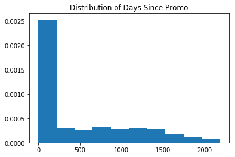

```python
plt.hist(sales_copy['days_since_promo2'].dt.days, normed=True)
plt.title('Distribution of Days Since Promo')
plt.show
```

```
<function matplotlib.pyplot.show(*args, **kw)>
```

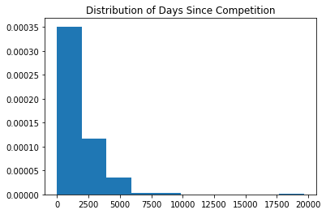

```python
plt.hist(sales_copy['days_since_competition'].dt.days, normed=True)
plt.title('Distribution of Days Since Competition')
plt.show
```

```python
#listing unique values in promo interval column and replacing with full month name
sales_copy['PromoInterval'].unique()
```

```
array([nan, 'Mar,Jun,Sept,Dec', 'Jan,Apr,Jul,Oct', 'Feb,May,Aug,Nov'],
      dtype=object)
```

```python
mth_map = {'Mar,Jun,Sept,Dec': 'March,June,September,December',
           'Jan,Apr,Jul,Oct': 'January,April,July,October',
          'Feb,May,Aug,Nov': 'February,May,August,November'}
sales_copy['PromoInterval'] = sales_copy['PromoInterval'].map(mth_map)
sales_copy['PromoInterval'] = sales_copy['PromoInterval'].astype(str).apply(lambda x: [i for i in x.split(',')])
```

```python
sales_copy['PromoInterval'].astype(str).unique()
```

```
array(["['nan']", "['March', 'June', 'September', 'December']",
       "['January', 'April', 'July', 'October']",
       "['February', 'May', 'August', 'November']"], dtype=object)
```

```python
sales_copy['promo2_int_mod'] = sales_copy.progress_apply(lambda x: ','.join([str(i) if x['month'] in x['PromoInterval'] else '0' for i in x['PromoInterval']]), axis=1)
```

```python
#replacing 0 lists
sales_copy.loc[((sales_copy['promo2_int_mod']=='0,0,0,0')|(sales_copy['promo2_int_mod']=='0')), 'promo2_int_mod']= 0
```

```python
sales_copy.columns
```

```
Index(['Store', 'date_s', 'Sales', 'Customers', 'Open', 'Promo',
       'StateHoliday', 'SchoolHoliday', 'year', 'day', 'iso_weeknum',
       'weekday', 'month', 'seasons', 'quarter', 'mapped_region', 'google_svi',
       'wc_days', 'num_asy_app', 'cpi', 'tmpc', 'relh', 'StoreType',
       'Assortment', 'CompetitionDistance', 'PromoInterval',
       'competition_since_date', 'promo_since_date', 'days_since_competition',
       'days_since_promo2', 'promo2_int_mod'],
      dtype='object')
```

```python
#subsetting required columns
sales_copy = sales_copy[['Store', 'date_s', 'Sales', 'Customers', 'Open', 'Promo',
                          'StateHoliday', 'SchoolHoliday', 'year', 'day', 'iso_weeknum',
                          'weekday', 'month', 'seasons', 'quarter', 'mapped_region', 'google_svi',
                          'wc_days', 'num_asy_app', 'cpi', 'tmpc', 'relh', 'StoreType',
                          'Assortment', 'CompetitionDistance', 'days_since_competition',
                          'days_since_promo2', 'promo2_int_mod']]
```

```python
sales_copy.loc[sales_copy['promo2_int_mod']!=0, 'promo2_int_mod'] = 1
```

```python
sales_copy['promo2_int_mod'].unique()
```

```
array([0, 1])
```

### Collected all exogenous data and combined with the sales dataset, also transformed store level data and combined with the sales dataset to create the ADS

```python
sales_copy.to_csv(cwd+r'/data/processed_data/sales_ads.csv')
```

```python
!jupyter nbconvert --to html ads_creation.ipynb
os.rename('ads_creation.html', 'index.html')
```

```
[NbConvertApp] Converting notebook ads_creation.ipynb to html
[NbConvertApp] Writing 513901 bytes to ads_creation.html
```

###### [Avinash Pasupulate - Linkedin Profile](https://www.linkedin.com/in/avinashpasupulate/)